# STAT5003 A2 | Linear Discriminant Analysis

W08G03 — Member A

2026-10-24

# 1 Research aim, hypotheses, and boundaries

**Research question (A1):** To what extent can demographic characteristics, education and socioeconomic circumstances predict an individual’s eight-category employment status (`Q279`)? This follows the A1 question and feature policy.

A1 hypotheses are that age helps distinguish Student and Retired respondents, gender is associated with Housewife, and education, household income, marital status and social class provide additional information. These are predictive associations, not causal effects.

Linear discriminant analysis (LDA) provides a computationally economical linear comparison to multinomial logistic regression. Classical LDA models class-specific means with a shared within-class covariance matrix. Under multivariate Gaussian class-conditional distributions, this gives linear decision boundaries. Here, dummy-coded survey categories are not Gaussian, and covariance equality is unlikely to hold exactly. LDA is therefore an empirical predictive benchmark; its assumptions are limitations, not verified properties of the survey.

We compare six predetermined candidates: three feature sets crossed with two class-prior policies. **Validation Macro F1 alone determines the main ranking.** The common 20% test partition is evaluated only after selection and final refitting. This document implements LDA only; comparisons against teammates’ fitted models must use their separately verified results. Survey weights are excluded for this individual-record predictive task, following the shared baseline contract.

# 2 Portable data ingestion and locked split

After materialising the shared CSV with `git lfs pull`, this file can be knitted using MASS, knitr and rmarkdown. It does not require saved models, generated results files or network access during execution. Knitting also writes model-comparison tables, test predictions, figures and a reproducibility bundle to `STAT5003_B_lda_results`, following the other model contributions. Override this location with `STAT5003_LDA_OUT_DIR` if needed.

```r
SEED <- 5003
TRAIN_FRACTION <- 0.80
TARGET_LABELS <- c("Full-time", "Part-time", "Self-employed", "Retired",
                   "Housewife", "Student", "Unemployed", "Other")
REQUIRED_COLUMNS <- c("Q279", "B_COUNTRY_ALPHA", "Q260", "Q262", "Q270",
                      "Q273", "Q274", "Q275", "Q286", "Q287", "Q288")
if (!requireNamespace("MASS", quietly = TRUE)) stop("Package MASS is required.")
input_name <- knitr::current_input(dir = TRUE)
document_dir <- if (length(input_name) == 1L && nzchar(input_name)) {
  dirname(normalizePath(input_name, mustWork = TRUE))
} else getwd()
OUT_DIR <- Sys.getenv("STAT5003_LDA_OUT_DIR",
                      file.path(document_dir, "STAT5003_B_lda_results"))
dir.create(OUT_DIR, recursive = TRUE, showWarnings = FALSE)
write_table <- function(x, name) {
  write.csv(x, file.path(OUT_DIR, name), row.names = FALSE)
}
save_plot <- function(name, draw, width = 2600, height = 1300) {
  png(file.path(OUT_DIR, name), width = width, height = height, res = 260)
  tryCatch(draw(), finally = dev.off())
  if (isTRUE(getOption("knitr.in.progress"))) draw()
  invisible(NULL)
}
```

The input is the unchanged shared CSV, resolved relative to this file or the working directory. Its expected Git LFS SHA-256 is `ee392676dbb42dde0ea74ebf643862f3900e7d13a7aa03842ed2d7665ac98ee0`. The local working copy used for this analysis was checked against that hash. Moving or modifying rows invalidates the shared split agreement.

```r
resolve_dataset <- function(filename = "WVS_Wave7_cleaned_for_modelling.csv") {
  override <- Sys.getenv("STAT5003_DATA_PATH", "")
  if (nzchar(override)) {
    if (!file.exists(override) || file.info(override)$size < 1000)
      stop("STAT5003_DATA_PATH must point to the materialised shared CSV.")
    return(normalizePath(override, mustWork = TRUE))
  }
  candidates <- getwd()
  if (requireNamespace("knitr", quietly = TRUE)) {
    f <- tryCatch(knitr::current_input(dir = TRUE), error = function(e) "")
    if (length(f) == 1L && nzchar(f))
      candidates <- c(candidates, dirname(normalizePath(f, mustWork = FALSE)))
  }
  candidates <- unique(c(candidates, dirname(candidates)))
  hits <- file.path(candidates, filename)
  hits <- hits[file.exists(hits)]
  if (!length(hits)) stop("Shared CSV not found; materialise it using git lfs pull.")
  if (file.info(hits[1])$size < 1000) stop("Input is an LFS pointer, not the dataset.")
  normalizePath(hits[1], mustWork = TRUE)
}
read_selected <- function(path, wanted) {
  cols <- names(read.csv(path, nrows = 0, check.names = FALSE))
  if (!all(wanted %in% cols)) stop("Missing required columns: ",
                                 paste(setdiff(wanted, cols), collapse = ", "))
  types <- rep("NULL", length(cols))
  types[match(wanted, cols)] <- NA_character_
  read.csv(path, colClasses = types, check.names = FALSE,
           stringsAsFactors = FALSE, na.strings = c("", "NA"))
}
stratified_indices <- function(y, fraction, seed) {
  set.seed(seed)
  groups <- split(seq_along(y), y, drop = TRUE)
  sort(unlist(lapply(groups, function(ii) sample(ii, floor(length(ii) * fraction))),
              use.names = FALSE))
}
csv_path <- resolve_dataset()
input_md5 <- unname(tools::md5sum(csv_path))
if (!identical(input_md5, "98bf573170f0cb6bd65a4e9a8070d4d8"))
  stop("CSV differs from the verified shared input. Confirm its version and row order with the team.")
wvs <- read_selected(csv_path, REQUIRED_COLUMNS)
stopifnot(nrow(wvs) == 95987L,
          all(as.character(wvs$Q279) %in% as.character(1:8)))
wvs$Outcome <- factor(as.character(wvs$Q279), levels = as.character(1:8),
                      labels = TARGET_LABELS)
train_id <- stratified_indices(wvs$Outcome, TRAIN_FRACTION, SEED)
test_id <- setdiff(seq_len(nrow(wvs)), train_id)
train <- wvs[train_id, , drop = FALSE]
dev_id <- stratified_indices(train$Outcome, 0.75, SEED + 2)
val_id <- setdiff(seq_len(nrow(train)), dev_id)
initial_train <- train[dev_id, , drop = FALSE]
validation <- train[val_id, , drop = FALSE]
stopifnot(length(intersect(train_id, test_id)) == 0L,
          length(intersect(dev_id, val_id)) == 0L,
          length(train_id) + length(test_id) == nrow(wvs),
          length(dev_id) + length(val_id) == nrow(train),
          nrow(initial_train) == 57587L, nrow(validation) == 19199L,
          length(test_id) == 19201L)
split_table <- data.frame(Class = TARGET_LABELS,
  Train = as.integer(table(initial_train$Outcome)),
  Validation = as.integer(table(validation$Outcome)),
  Test = as.integer(table(wvs$Outcome[test_id])))
write_table(split_table, "shared_class_counts.csv")
partition <- rep("Test", nrow(wvs))
partition[train_id[dev_id]] <- "Train"
partition[train_id[val_id]] <- "Validation"
write_table(data.frame(row_id = seq_len(nrow(wvs)), split = partition),
            "shared_split_row_ids.csv")
saveRDS(list(train_id = train_id, test_id = test_id, dev_id = dev_id, val_id = val_id,
             input_md5 = input_md5), file.path(OUT_DIR, "shared_split_indices.rds"))
```

Table 1. Class counts in the shared Train, Validation and Test partitions.

| Class | Train | Validation | Test |
| --- | --- | --- | --- |
| Full-time | 20981 | 6994 | 6994 |
| Part-time | 4959 | 1653 | 1654 |
| Self-employed | 8250 | 2751 | 2751 |
| Retired | 7247 | 2416 | 2416 |
| Housewife | 7642 | 2548 | 2548 |
| Student | 3382 | 1128 | 1128 |
| Unemployed | 4431 | 1477 | 1478 |
| Other | 695 | 232 | 232 |

This is an individual-level random holdout, not a test in new countries or years. All initial fitting uses 57,587 records; no training cap is needed for LDA. The final model is refitted on 76,786 development records.

# 3 Pre-registered predictors and verified FY2021 World Bank context

The **core** uses age, gender, marital status, education, self-rated social class and household income bracket. **Extended without context** adds household size, number of children and savings. **Extended with context** additionally includes the shared baseline’s verified FY2021 national income proxy. Raw country, respondent IDs, survey administration variables, weights and employment-proxy questions are excluded. National income group and household income are distinct concepts.

The country map below matches the canonical FY2021 crosswalk verified against the frozen official historical workbook in `source_evidence/`. Taiwan is High and Venezuela is Upper-middle. Northern Ireland explicitly inherits the UK’s High group; it has no independent official row. The unused `Unclassified` dictionary level is retained without any country assignment. This fixed-vintage proxy is not survey-year-specific; candidates without it provide sensitivity checks.

```r
WB_GROUPS <- list(
  Low = c("ETH", "TJK"),
  `Lower-middle` = c("BGD", "BOL", "EGY", "IND", "KEN", "KGZ", "MAR", "MMR", "MNG",
                     "NGA", "NIC", "PAK", "PHL", "TUN", "UKR", "UZB", "VNM", "ZWE"),
  `Upper-middle` = c("ARG", "ARM", "BRA", "CHN", "COL", "ECU", "GTM", "IDN", "IRN",
                     "IRQ", "JOR", "KAZ", "LBN", "LBY", "MDV", "MEX", "MYS", "PER",
                     "RUS", "SRB", "THA", "TUR", "VEN"),
  High = c("AND", "AUS", "CAN", "CHL", "CYP", "CZE", "DEU", "GBR", "GRC", "HKG", "JPN",
           "KOR", "MAC", "NIR", "NLD", "NZL", "PRI", "ROU", "SGP", "SVK", "TWN", "URY",
           "USA"),
  Unclassified = character(0)
)
country_map <- setNames(rep(names(WB_GROUPS), lengths(WB_GROUPS)),
                        unlist(WB_GROUPS, use.names = FALSE))
stopifnot(!anyDuplicated(names(country_map)))
unknown <- setdiff(unique(as.character(wvs$B_COUNTRY_ALPHA)), names(country_map))
if (length(unknown)) stop("Unmapped countries: ", paste(unknown, collapse = ", "))
add_context <- function(raw) {
  raw$Income_Group <- unname(country_map[as.character(raw$B_COUNTRY_ALPHA)])
  raw
}
initial_train <- add_context(initial_train)
validation <- add_context(validation)
```

# 4 Fit-partition-only preprocessing

New numerical imputation and standardisation parameters are fitted on the fitting partition only. Missing/non-numeric numerical responses are replaced by training medians, with missingness indicators. Fixed questionnaire category levels are encoded with treatment contrasts; no equal spacing is assumed. Zero within-class variance columns and linearly dependent within-class columns are removed using the fitting partition alone. The same columns are then used for validation or test. This avoids singular-covariance failures caused by absent `Missing` categories and redundant dummy columns.

**Inherited limitation:** A1 mode-imputed fixed-choice variables before the split. We cannot recover original item missingness from this cleaned CSV. The new pipeline avoids additional fitted-preprocessing leakage, but cannot claim to repair that earlier leakage.

```r
NUMERIC_KEYS <- c(Age = "Q262", HouseholdSize = "Q270", Children = "Q274")
CATEGORY_KEYS <- list(
  Gender = as.character(1:2), Marital = as.character(1:6),
  Education = as.character(0:8), SocialClass = as.character(1:5),
  IncomeBracket = as.character(1:10), Savings = as.character(1:4),
  Income_Group = c("Low", "Lower-middle", "Upper-middle", "High", "Unclassified"))
CATEGORY_SOURCES <- c(Gender = "Q260", Marital = "Q273", Education = "Q275",
  SocialClass = "Q287", IncomeBracket = "Q288", Savings = "Q286",
  Income_Group = "Income_Group")
numeric_value <- function(v) {
  x <- suppressWarnings(as.numeric(as.character(v)))
  x[!is.finite(x)] <- NA_real_
  x
}
learn_recipe <- function(raw) {
  num <- lapply(NUMERIC_KEYS, function(k) numeric_value(raw[[k]]))
  med <- vapply(num, function(x) {
    if (all(is.na(x))) stop("A numeric feature is entirely missing in fitting data.")
    median(x, na.rm = TRUE)
  }, 0.0)
  filled <- Map(function(x, m) { x[is.na(x)] <- m; x }, num, med)
  mu <- vapply(filled, mean, 0.0)
  sigma <- vapply(filled, sd, 0.0)
  sigma[!is.finite(sigma) | sigma == 0] <- 1
  list(median = med, mean = mu, sd = sigma)
}
apply_recipe <- function(raw, recipe) {
  out <- data.frame(row.names = seq_len(nrow(raw)))
  for (nm in names(NUMERIC_KEYS)) {
    x <- numeric_value(raw[[NUMERIC_KEYS[[nm]]]])
    missing <- is.na(x)
    x[missing] <- recipe$median[[nm]]
    out[[nm]] <- (x - recipe$mean[[nm]]) / recipe$sd[[nm]]
    out[[paste0(nm, "_missing")]] <- as.integer(missing)
  }
  for (nm in names(CATEGORY_KEYS)) {
    v <- trimws(as.character(raw[[CATEGORY_SOURCES[[nm]]]]))
    v[is.na(v) | !(v %in% CATEGORY_KEYS[[nm]])] <- "Missing"
    out[[nm]] <- factor(v, levels = c(CATEGORY_KEYS[[nm]], "Missing"))
  }
  out
}
core <- c("Age", "Age_missing", "Gender", "Marital", "Education",
          "SocialClass", "IncomeBracket")
extended <- c(core, "HouseholdSize", "HouseholdSize_missing", "Children",
              "Children_missing", "Savings")
SPECIFICATIONS <- list(core_linear = core, extended_no_income_group = extended,
                       extended_linear = c(extended, "Income_Group"))
design_matrix <- function(processed, spec) {
  # Explicit treatment contrasts avoid dependency on the user's R options.
  cats <- intersect(SPECIFICATIONS[[spec]], names(CATEGORY_KEYS))
  contrasts <- lapply(processed[cats], function(x)
    stats::contr.treatment(levels(x), base = 1))
  mm <- model.matrix(reformulate(SPECIFICATIONS[[spec]]), data = processed,
                     contrasts.arg = contrasts)
  mm[, colnames(mm) != "(Intercept)", drop = FALSE]
}
learn_columns <- function(x, y) {
  # Residuals about class means identify rank of the pooled within-class design.
  class_means <- rowsum(x, y, reorder = TRUE) / as.numeric(table(y))
  within <- x - class_means[as.integer(y), , drop = FALSE]
  s <- sqrt(colSums(within^2) / (nrow(x) - nlevels(y)))
  usable <- which(is.finite(s) & s > 1e-8)
  if (!length(usable)) stop("No usable within-class variation.")
  q <- qr(sweep(within[, usable, drop = FALSE], 2, s[usable], "/"),
          tol = 1e-8, LAPACK = FALSE)
  keep <- usable[q$pivot[seq_len(q$rank)]]
  colnames(x)[sort(keep)]
}
fit_lda <- function(raw, spec, prior_policy) {
  recipe <- learn_recipe(raw)
  x <- design_matrix(apply_recipe(raw, recipe), spec)
  columns <- learn_columns(x, raw$Outcome)
  prior <- if (prior_policy == "equal") rep(1/8, 8) else
    as.numeric(prop.table(table(raw$Outcome)))
  fit <- MASS::lda(x = x[, columns, drop = FALSE], grouping = raw$Outcome,
                    prior = prior, method = "moment", tol = 1e-8)
  list(model = fit, recipe = recipe, columns = columns, spec = spec,
       prior_policy = prior_policy, dropped = setdiff(colnames(x), columns))
}
predict_lda <- function(object, raw) {
  x <- design_matrix(apply_recipe(raw, object$recipe), object$spec)
  predict(object$model, newdata = x[, object$columns, drop = FALSE])
}
```

# 5 Evaluation and predetermined validation search

Empirical priors use fitting-set class proportions; equal priors assign 1/8 to each class. Equal priors change the decision rule and may help rare classes, but are not guaranteed to improve Macro F1. We do not resample records or tune probability thresholds. Classical LDA has no neighbour count, tree depth or regularisation penalty; this is feature/prior selection, not a regularised-LDA experiment. Ties are resolved by Weighted F1, fewer retained columns, then the predetermined candidate order. All candidates use the same fitting records.

```r
evaluate_8class <- function(truth, pred) {
  tr <- factor(as.character(truth), levels = TARGET_LABELS)
  pr <- factor(as.character(pred), levels = TARGET_LABELS)
  stopifnot(length(tr) == length(pr), length(tr) > 0L)
  if (anyNA(tr) || anyNA(pr)) stop("Unknown/missing prediction class")
  cm <- table(True = tr, Predicted = pr)
  tp <- diag(cm); support <- rowSums(cm); predicted <- colSums(cm)
  precision <- ifelse(predicted > 0, tp / predicted, 0)
  recall <- ifelse(support > 0, tp / support, 0)
  f1 <- ifelse(precision + recall > 0,
               2 * precision * recall / (precision + recall), 0)
  list(overall = data.frame(Macro_F1 = mean(f1),
       Weighted_F1 = sum(support * f1) / sum(support),
       Accuracy = sum(tp) / sum(cm)),
       by_class = data.frame(Class = TARGET_LABELS, Support = as.integer(support),
         Precision = as.numeric(precision), Recall = as.numeric(recall),
         F1 = as.numeric(f1)), confusion = cm)
}
```

Table 2. Six LDA candidates ranked using validation only.

| Candidate | Specification | Prior | Columns | Macro_F1 | Weighted_F1 | Accuracy | Seconds |
| --- | --- | --- | --- | --- | --- | --- | --- |
| 3 | extended_linear | empirical | 39 | 0.3395 | 0.4592 | 0.5101 | 1.00 |
| 6 | extended_linear | equal | 39 | 0.3362 | 0.4047 | 0.4143 | 1.02 |
| 2 | extended_no_income_group | empirical | 36 | 0.3291 | 0.4451 | 0.5023 | 0.89 |
| 5 | extended_no_income_group | equal | 36 | 0.3260 | 0.3900 | 0.4015 | 1.00 |
| 1 | core_linear | empirical | 29 | 0.3251 | 0.4402 | 0.4974 | 1.14 |
| 4 | core_linear | equal | 29 | 0.3222 | 0.3852 | 0.3984 | 0.68 |

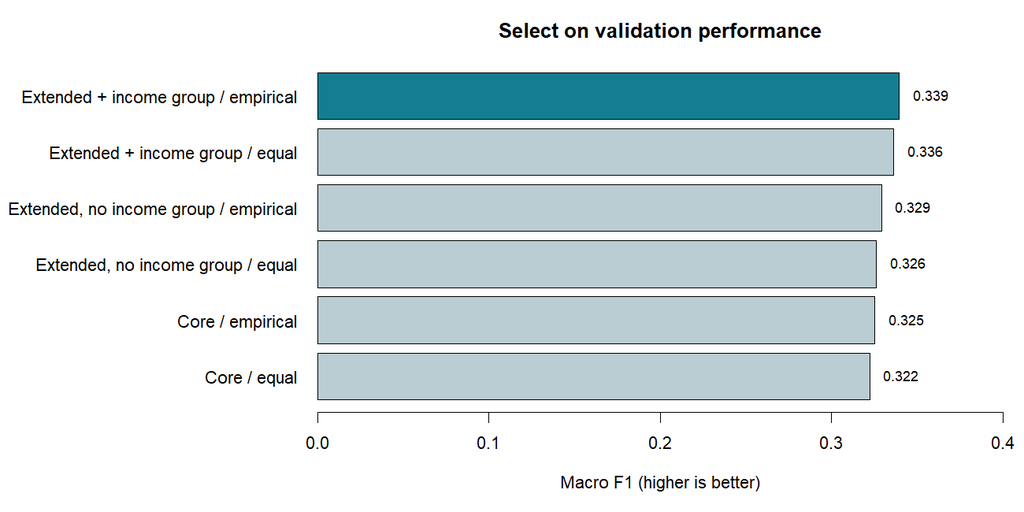

Figure 1. Validation Macro F1 for the six predetermined candidates. Each bar uses the same validation records.

```r
grid <- expand.grid(Specification = names(SPECIFICATIONS),
                    Prior = c("empirical", "equal"), stringsAsFactors = FALSE)
write_table(grid, "prespecified_search_grid.csv")
candidate_fits <- vector("list", nrow(grid))
validation_rows <- vector("list", nrow(grid))
for (i in seq_len(nrow(grid))) {
  elapsed <- system.time({
    candidate_fits[[i]] <- fit_lda(initial_train, grid$Specification[i], grid$Prior[i])
    pred <- predict_lda(candidate_fits[[i]], validation)$class
  })[["elapsed"]]
  scores <- evaluate_8class(validation$Outcome, pred)$overall
  validation_rows[[i]] <- data.frame(Candidate = i, grid[i, ],
    Columns = length(candidate_fits[[i]]$columns), scores, Seconds = elapsed)
}
validation_results <- do.call(rbind, validation_rows)
ranking <- with(validation_results,
  order(-Macro_F1, -Weighted_F1, Columns, Candidate))
best_id <- ranking[1]
selected <- validation_results[best_id, , drop = FALSE]
write_table(validation_results[ranking, ], "validation_tuning_results.csv")
write_table(selected, "selected_validation_configuration.csv")
```

The selected candidate is **extended_linear with empirical priors**, with validation Macro F1 **0.3395**. Feature and prior choices are frozen here, before test prediction. This is a single validation holdout; small score differences are not evidence of statistically significant superiority.

# 6 Final train refit and single held-out test

```r
train <- add_context(train)
final_seconds <- system.time({
  final_fit <- fit_lda(train, selected$Specification, selected$Prior)
})[["elapsed"]]
test <- add_context(wvs[test_id, , drop = FALSE])
test_prediction <- predict_lda(final_fit, test)
test_evaluation <- evaluate_8class(test$Outcome, test_prediction$class)
stopifnot(nrow(test_prediction$posterior) == nrow(test),
          all(is.finite(test_prediction$posterior)),
          max(abs(rowSums(test_prediction$posterior) - 1)) < 1e-8,
          sum(test_evaluation$confusion) == nrow(test))
majority <- names(which.max(table(train$Outcome)))
majority_evaluation <- evaluate_8class(test$Outcome, rep(majority, nrow(test)))
test_comparison <- rbind(
  data.frame(Model = "Training-majority reference", majority_evaluation$overall),
  data.frame(Model = "Selected LDA", test_evaluation$overall))
write_table(test_comparison, "test_model_comparison.csv")
write_table(test_evaluation$overall, "lda_test_metrics.csv")
write_table(test_evaluation$by_class, "lda_per_class_metrics.csv")
write_table(as.data.frame(test_evaluation$confusion), "lda_confusion_matrix.csv")
write_table(data.frame(row_id = test_id, truth = test$Outcome,
                        prediction = test_prediction$class), "lda_test_predictions.csv")
saveRDS(list(model = final_fit$model, recipe = final_fit$recipe,
  columns = final_fit$columns, specification = final_fit$spec,
  prior_policy = final_fit$prior_policy, dropped = final_fit$dropped,
  features = SPECIFICATIONS[[final_fit$spec]], country_map = country_map,
  input_md5 = input_md5, baseline_blob = "7c83716a1f8186a40a17ab124da8bd9b8bfee430",
  selected = selected, validation_results = validation_results,
  split = list(train_id = train_id, test_id = test_id, dev_id = dev_id, val_id = val_id),
  RNG = RNGkind(), session = sessionInfo()), file.path(OUT_DIR, "lda_model_bundle.rds"))
```

Table 3. Final Test performance after refitting the selected configuration on 80% of the data.

| Model | Macro_F1 | Weighted_F1 | Accuracy |
| --- | --- | --- | --- |
| Training-majority reference | 0.0667 | 0.1945 | 0.3643 |
| Selected LDA | 0.3407 | 0.4617 | 0.5148 |

Table 4. Final Test precision, recall and F1 for all eight employment classes.

| Class | Support | Precision | Recall | F1 |
| --- | --- | --- | --- | --- |
| Full-time | 6994 | 0.5654 | 0.7358 | 0.6395 |
| Part-time | 1654 | 0.6000 | 0.0018 | 0.0036 |
| Self-employed | 2751 | 0.3683 | 0.1687 | 0.2314 |
| Retired | 2416 | 0.6155 | 0.7508 | 0.6765 |
| Housewife | 2548 | 0.4744 | 0.5844 | 0.5237 |
| Student | 1128 | 0.3678 | 0.7190 | 0.4866 |
| Unemployed | 1478 | 0.2918 | 0.1062 | 0.1558 |
| Other | 232 | 0.1667 | 0.0043 | 0.0084 |

Table 5. Final fitting size, encoded dimension and measured fitting time.

| Final_fit_N | Test_N | Encoded_columns | Refit_seconds |
| --- | --- | --- | --- |
| 76786 | 19201 | 39 | 1.28 |

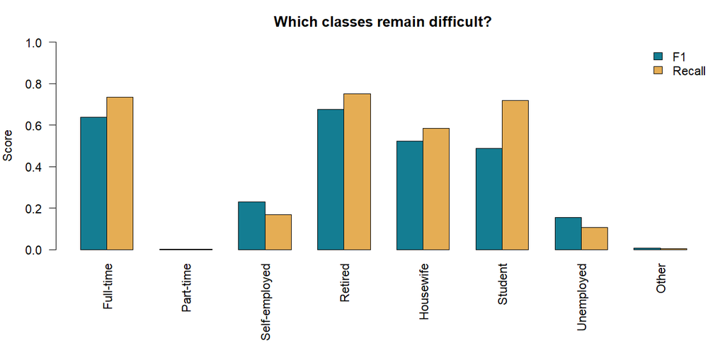

Figure 2. Final Test per-class F1 and recall; Table 4 reports class support.

Table 6. Final Test confusion counts: rows are actual classes and columns are predictions.

|  | Full-time | Part-time | Self-employed | Retired | Housewife | Student | Unemployed | Other |
| --- | --- | --- | --- | --- | --- | --- | --- | --- |
| Full-time | 5146 | 0 | 379 | 356 | 485 | 513 | 114 | 1 |
| Part-time | 900 | 3 | 124 | 159 | 228 | 186 | 54 | 0 |
| Self-employed | 1126 | 0 | 464 | 222 | 595 | 240 | 103 | 1 |
| Retired | 392 | 0 | 89 | 1814 | 95 | 10 | 15 | 1 |
| Housewife | 654 | 0 | 28 | 241 | 1489 | 90 | 46 | 0 |
| Student | 257 | 1 | 5 | 4 | 17 | 811 | 33 | 0 |
| Unemployed | 520 | 0 | 144 | 107 | 218 | 330 | 157 | 2 |
| Other | 106 | 1 | 27 | 44 | 12 | 25 | 16 | 1 |

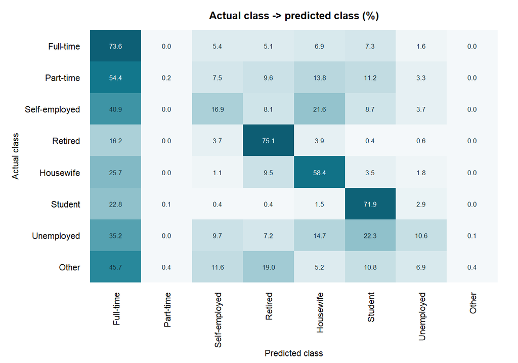

Figure 3. Final Test confusion matrix normalised within each actual class. Cell percentages may differ from 100% after rounding.

# 7 Interpretation and remaining limitations

The final LDA achieves test Macro F1 **0.3407**, Weighted F1 **0.4617** and accuracy **51.48%**. Its Macro F1 exceeds the training-majority reference by **0.2739**. The highest per-class F1 is for **Retired**; the lowest is for **Part-time**. These results answer the research question in terms of predictive performance, not causal explanations or evidence that interventions would change employment.

- **Imbalance:** report every class, including Other. Accuracy alone can conceal poor minority-class performance; equal priors are assessed by validation rather than presumed beneficial.
- **Model form:** common covariance and Gaussian assumptions are imperfect for mixed survey variables. Linear boundaries may miss age-related curvature and interactions that teammates’ nonlinear models can represent.
- **Data limitations:** inherited pre-split mode imputation, a fixed-vintage FY2021 national income proxy with a documented NIR inheritance assumption, self-reported categories and pooling across countries limit interpretation.
- **Scope and uncertainty:** one fixed random individual holdout cannot establish transportability to future surveys or new countries. Repeated within-development cross-validation would help assess selection stability in a subsequent study.
- **Team handoff:** use the selected LDA test row and the eight-class table for model comparison. Do not claim LDA is the best of five until all five comparable results are available. Knit this contribution to generate the model-specific result directory; the CSV tables and figures can then be used in the group report.

The treatment-coded design and within-class rank checks are specific to LDA. Full one-hot encoding is useful for the distance-based KNN and SVM implementations, but retaining every redundant indicator would make LDA’s covariance estimation singular. Agreement on source features and sample splits therefore does not require identical model-matrix representations across the five classifiers.

## 7.1 References

Venables, W. N., & Ripley, B. D. (2002). *Modern applied statistics with S* (4th ed.). Springer. https://doi.org/10.1007/978-0-387-21706-2

*Linear discriminant analysis*. (n.d.). In *MASS reference manual*. https://stat.ethz.ch/R-manual/R-devel/library/MASS/html/lda.html

World Values Survey Association. (n.d.). *WVS Wave 7 (2017–2022): Data and documentation*. https://www.worldvaluessurvey.org/WVSDocumentationWV7.jsp